# Lab 6

Kevin Wong

December 5, 2018

This dataset found in “hitters.csv” records the salary of n = 263 Major League Baseball players during the 1987 season as well as p = 19 statistics associated with the performance of each player during the previous season. Specifically,the dataset contains observations from the following variables:

•AtBat: Number oftimes at bat in 1986  
•Hits: Number of hits in 1986  
•HmRun: Number of home runs in 1986  
•Runs:Number of runs in 1986  
•RBI: Number of runs batted in in 1986  
•Walks: Number of walks in 1986  
•Years: Number of years in the major leagues  
•CAtBat: Number of times at bat during his career •CHits: Number of hits during his career  
•CHmRun: Number of home runs during his career  
•CRuns: Number of runs during his career  
•CRBI: Number of runs batted in during his career  
•CWalks: Number of walks during his career  
•League: A categorical variablewith levels A(for American) and N(for National) indicating the player’s league at the end of 1986  
•Division: A factor with levels E(for East) and W(for West) indicating the player’s division at the end of 1986  
•PutOuts: Number of put outs in 1986  
•Assists: Number of assistsin 1986  
•Errors: Number of errors in 1986  
•Salary: 1987 annual salary on opening day in thousands of dollars  
•NewLeague: A factor with levels Aand Nindicating the player’s league at the beginning of 1987

### Importing Data

```r
setwd("/Users/kevinwong2014/documents/usf/fall2018/linearregression")
df <- read.csv(file = "hitters.csv", header = T)
n <- dim(df)[1]
```

Let’s examine the first five rows of the dataset.

```r
df[1:5,]
```

```
##   AtBat Hits HmRun Runs RBI Walks Years CAtBat CHits CHmRun CRuns CRBI
## 1   315   81     7   24  38    39    14   3449   835     69   321  414
## 2   479  130    18   66  72    76     3   1624   457     63   224  266
## 3   496  141    20   65  78    37    11   5628  1575    225   828  838
## 4   321   87    10   39  42    30     2    396   101     12    48   46
## 5   594  169     4   74  51    35    11   4408  1133     19   501  336
##   CWalks League Division PutOuts Assists Errors Salary NewLeague
## 1    375      N        W     632      43     10  475.0         N
## 2    263      A        W     880      82     14  480.0         A
## 3    354      N        E     200      11      3  500.0         N
## 4     33      N        E     805      40      4   91.5         N
## 5    194      A        W     282     421     25  750.0         A
```

Setting seed for reproducibility.

```r
set.seed(1)
```

### Splitting Data into Train and Test Sets

Generating a random set of training indices.

```r
train_idx <- sample(1:n, size = 210)
length(train_idx)
```

```
## [1] 210
```

Subtract the training indices out of the (1:n) to get the test indices.

```r
test_idx <- (1:n)[-train_idx]
length(test_idx)
```

```
## [1] 53
```

```r
library(glmnet)
```

### Fiting Lasso and Ridge Regression Models

First, we generate a grid for lambda values to iterate over to search for the optimal lambda parameter.

```r
grid <- 10^seq(-3, 10, length = 1000)
```

```r
X <- model.matrix(Salary ~ ., df)[,-1]
y <- df$Salary
```

Iterating over the lambdas to generate 1000 ridge regression models and plotting lambda vs coefficients. Each colored line represents a feature’s corresponding beta value as lambda increases and they are shrunk closer to 0.

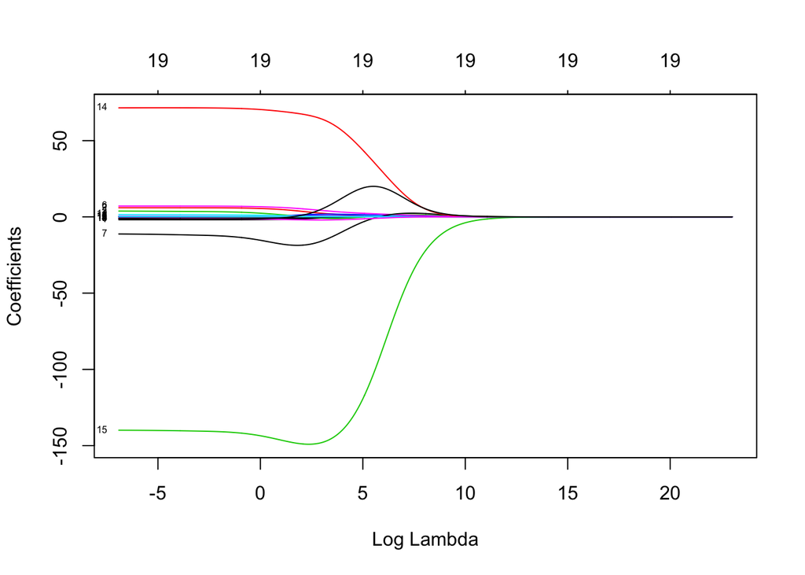

```r
ridge.mod <- glmnet(X[train_idx,], y[train_idx], alpha=0, lambda=grid)
plot(ridge.mod, xvar = "lambda", label = TRUE)
```

Iterating over the lambdas to generate 1000 lasso regression models and plotting lambda vs coefficients.

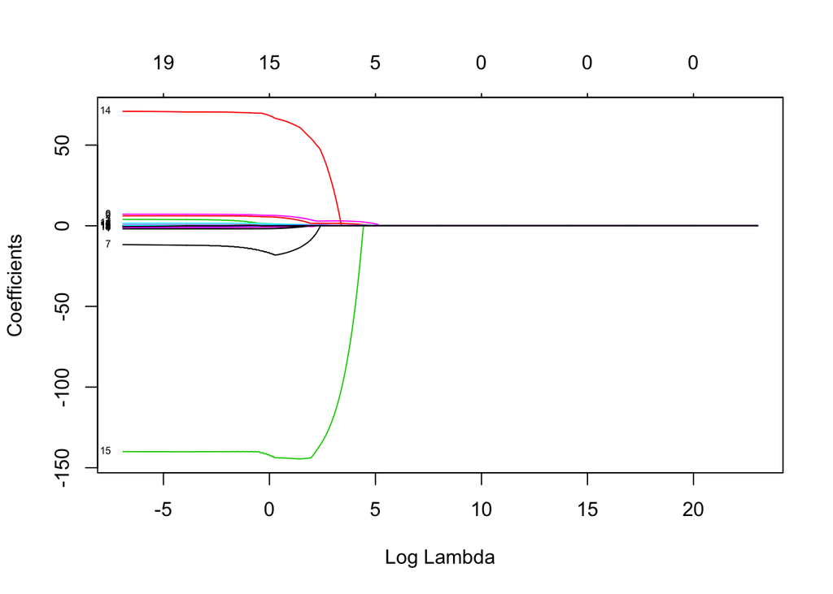

```r
lasso.mod <- glmnet(X[train_idx,], y[train_idx], alpha=1, lambda=grid)
plot(lasso.mod, xvar = "lambda", label = TRUE)
```

### Finding the Best Ridge Model

Use default k=10 fold cross validation on the training data.

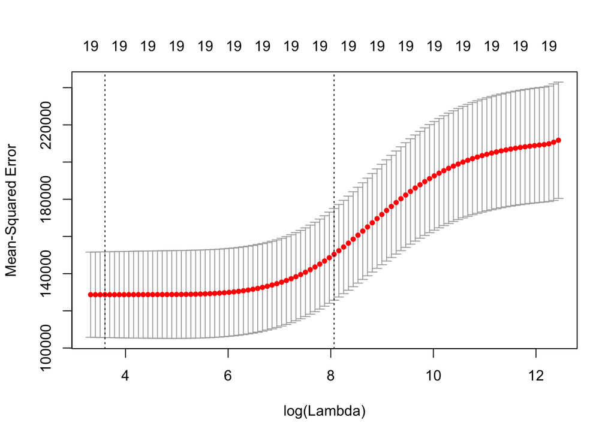

```r
cv.out <- cv.glmnet(X[train_idx,], y[train_idx], alpha=0)
plot(cv.out)
```

The best lambda value:

```r
bestlam.r <- cv.out$lambda.min
bestlam.r
```

```
## [1] 36.57596
```

```r
log(bestlam.r)
```

```
## [1] 3.599391
```

The corresponding beta coefficients:

```r
predict(ridge.mod, s=bestlam.r, type = "coefficients")
```

```
## 20 x 1 sparse Matrix of class "dgCMatrix"
##                         1
## (Intercept)   96.20755750
## AtBat         -0.44207671
## Hits           1.75315245
## HmRun         -1.03581063
## Runs           1.76883011
## RBI            0.47185579
## Walks          3.54663158
## Years        -12.40899462
## CAtBat         0.01059229
## CHits          0.12975834
## CHmRun         0.59712696
## CRuns          0.27966570
## CRBI           0.19968740
## CWalks        -0.24831622
## LeagueN       60.19481194
## DivisionW   -144.25121942
## PutOuts        0.19241907
## Assists        0.05994802
## Errors        -1.94466586
## NewLeagueN     9.25633768
```

### Finding the Best Lasso Model

Use default k=10 fold cross validation on the training data.

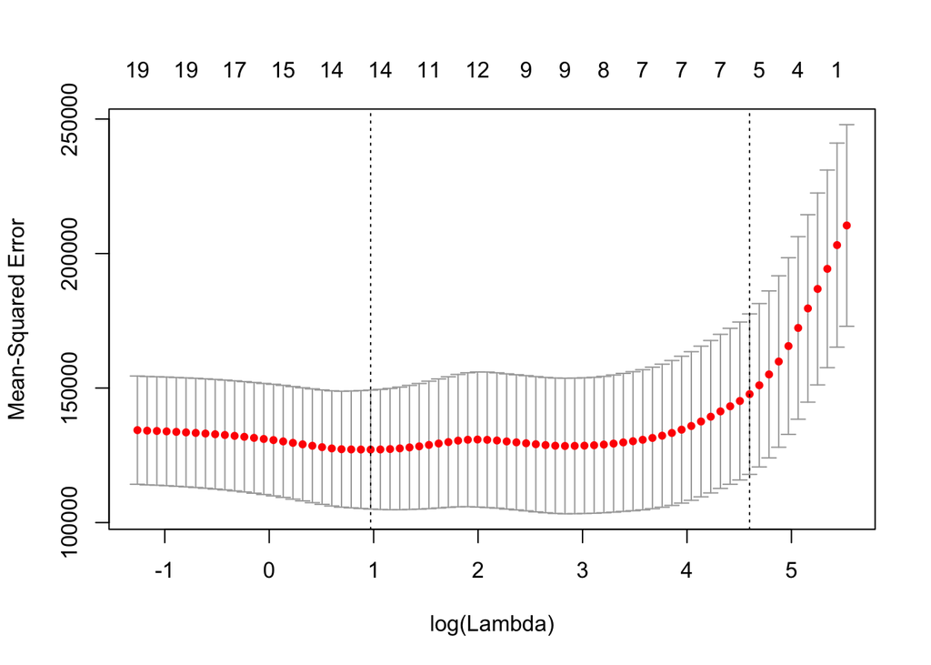

```r
cv.out <- cv.glmnet(X[train_idx,], y[train_idx], alpha=1)
plot(cv.out)
```

The best lambda value:

```r
bestlam.l <- cv.out$lambda.min
bestlam.l
```

```
## [1] 2.64108
```

```r
log(bestlam.l)
```

```
## [1] 0.971188
```

The corresponding beta coefficients:

```r
predict(lasso.mod, s=bestlam.l, type = "coefficients")[1:12,]
```

```
## (Intercept)       AtBat        Hits       HmRun        Runs         RBI
## 156.0907610  -1.2967627   4.4149056   0.4127465   0.0000000   0.0000000
##       Walks       Years      CAtBat       CHits      CHmRun       CRuns
##   5.7294339 -15.9942211   0.0000000   0.0000000   0.4652573   0.9290229
```

### Compare and Contrast the Models

The comparison between the optimal lasso and ridge models begins with an examination of the lambda term. Using a lasso penalization term, the lambda ends up being a small value close to 2 whereas the lambda associated with a ridge penalty term is an order of magnitude larger. Moreover, the variable inclusion/exlclusion is different as lasso regularization allows for some beta terms to be shrunk completely to 0 and thus eliminated from the model. In contrast ridge regularization shrinks these same terms (that were eliminated in lasso) to instead values close to and approaching 0. The last difference between the two models is that the betas even for significant terms still vary by a considerable margin.

### Lasso, Ridge, and Stepwise Model Performance on Hold-Out Data

```r
library(boot)

# Calculating predictive RMSE for ridge regression
ridge.pred <- predict(ridge.mod, s=bestlam.r, newx=X[test_idx,])
rmse_ridge <- sqrt(mean((ridge.pred - y[test_idx])^2))

# Calculating predictive RMSE for lasso regression
lasso.pred <- predict(lasso.mod, s=bestlam.l, newx=X[test_idx,])
rmse_lasso <- sqrt(mean((lasso.pred - y[test_idx])^2))

# Calculating predictive RMSE from the Stepwise Model derived in Lab 5
glm_stepwise <- glm(Salary ~ CRBI + Hits + PutOuts + Division + AtBat +  Walks + CWalks + CRuns + CAtBat + Assists, data = df)
stepwise.pred <- predict(object = glm_stepwise, newdata = df[test_idx,])
rmse_stepwise <- sqrt(mean((stepwise.pred - y[test_idx])^2))
```

```r
results <- data.frame(r = ridge.pred, l = lasso.pred, stepwise = stepwise.pred, actual = y[sort(test_idx)])
colnames(results) <- c("ridge","lasso","stepwise","actual")
results
```

```
##          ridge      lasso  stepwise   actual
## 1    412.03056  350.40550  365.0696  475.000
## 3   1062.01495 1159.12101 1127.2264  500.000
## 9    810.63783  716.74321  701.1380 1100.000
## 10   886.22962  884.88827  926.1012  517.143
## 12   562.92379  558.51389  456.2901  550.000
## 18   580.06531  554.47611  395.2473  100.000
## 19   381.84453  379.44257  355.7194  115.000
## 24   513.21267  497.81698  545.2444  750.000
## 26   838.78536  761.07717  800.7371  900.000
## 27   264.73413  206.38729  130.4817  110.000
## 28   597.75730  622.47440  641.1984  612.500
## 35   350.60472  385.59097  388.6441  215.000
## 38   741.03492  726.44559  817.9795  875.000
## 40   676.60262  684.85255  698.6523 1200.000
```

[output cut: 39 more lines]

```r
rmse_lasso
```

```
## [1] 262.5244
```

```r
rmse_ridge
```

```
## [1] 270.1842
```

```r
rmse_stepwise
```

```
## [1] 224.9033
```

Based on these root mean squared error values, the stepwise model is the best performing on unseen data. This is expected, as the stepwise selection process involves consideration of many distinct models and incorporates a comparison of an accuracy metric within the selection process itself. Instead, ridge and lasso regularization are approximation techniques that shrink betas from the full model down to optimal values given a penalty term. Consequently, they sacrifice marginal gains in accuracy for speed.